# summarize results v5a

hbeale

21 December, 2020

```r
library(scales) # for comma_format
library(tidyverse)
library(dplyr)
library(tidyr)
library(janitor)
```

```r
library(cowplot)
```

## Summarize results of bulk processing for outlier lead accuracy project

This data comes from the CKCC1 outlier results.

## Identify input data

```r
# data_release_id <- "CKCC_outlier_lead_accuracy.results.2020_07_17"
# outlier_probability_output_CKCC_2020_12_03.tsv.gz
```

# Load data

```r
#gathered_results <- read_tsv(paste0("bulk_results.", data_release_id, ".tsv.gz")) %>%
#  rename(Mean_Accuracy = `Mean Accuracy`)

gathered_results_raw <- read_tsv("2020_12_03/outlier_probability_output_CKCC_2020_12_04.tsv.gz")
gathered_results <- gathered_results_raw %>%
  select(Sample, Gene, Type, Expression,
         Threshold, MEND_depth = `Mend depth`,
         effective_length = `Gene length`,
         Mean_Accuracy = `Probability of being an outlier`) %>%
  mutate(`Percent difference` = 100 * ((abs(Expression - Threshold)) / Expression)) %>%
  drop_na(Mean_Accuracy)

# Results including NAs

gathered_results_with_nas <- gathered_results_raw %>%
  select(Sample, Gene, Type, Expression,
         Threshold, MEND_depth = `Mend depth`,
         effective_length = `Gene length`,
         Mean_Accuracy = `Probability of being an outlier`) %>%
  mutate(`Percent difference` = 100 * ((abs(Expression - Threshold)) / Expression))
```

# Add bin info

```r
expression_bin_boundaries <- c(0, 1, 3, 5, 7, 10, 20)
mend_depth_bin_boundaries <- c(0, seq(2, 46, 4), Inf)*1E6
length_bin_boundaries <- c(0, 100, 450, 800, 1500, 4000, Inf)


make_bin_names <- function(boundaries = 1:10){
  raw_names <- paste0(boundaries, "-", lead(boundaries)) %>% str_replace("-Inf", "+")
  raw_names[1:(length(boundaries)-1)]
}


expression_bin_names <- make_bin_names(expression_bin_boundaries)
mend_depth_bin_names <- make_bin_names(mend_depth_bin_boundaries/1e6)
length_bin_names <- make_bin_names(length_bin_boundaries)

bulk_results <- gathered_results %>%
  mutate(Expression_bin = cut(Expression, expression_bin_boundaries,
                              labels = expression_bin_names,
                        include.lowest = TRUE),
         MEND_bin = cut(MEND_depth, mend_depth_bin_boundaries, labels = mend_depth_bin_names),
         length_bin = cut(effective_length, length_bin_boundaries, labels = length_bin_names,
                                      include.lowest = TRUE)
         )

# Results including NAs

bulk_results_with_nas <- gathered_results_with_nas %>%
  mutate(Expression_bin = cut(Expression, expression_bin_boundaries,
                              labels = expression_bin_names,
                        include.lowest = TRUE),
         MEND_bin = cut(MEND_depth, mend_depth_bin_boundaries, labels = mend_depth_bin_names),
         length_bin = cut(effective_length, length_bin_boundaries, labels = length_bin_names,
                                      include.lowest = TRUE)
         )
```

# How many bins are possible? How many contain entries?

```r
print("How many bins are possible?")
```

```
## [1] "How many bins are possible?"
```

```r
(length(expression_bin_boundaries)-1) * (length(mend_depth_bin_boundaries)-1) * (length(length_bin_boundaries)-1)
```

```
## [1] 468
```

```r
bin_check <- bulk_results %>%
  group_by(Expression_bin, MEND_bin, length_bin) %>%
  summarize(n_entries_per_bin = n())
print("How many bins contain entries in this data?")
```

```
## [1] "How many bins contain entries in this data?"
```

```r
nrow(bin_check)
```

```
## [1] 310
```

```r
print("What is the range of the number of entries per bin?")
```

```
## [1] "What is the range of the number of entries per bin?"
```

```r
bin_check %>%
  pull(n_entries_per_bin) %>%
  summary
```

```
##    Min. 1st Qu.  Median    Mean 3rd Qu.    Max.
##   13.00  100.00  100.00   89.08  100.00  100.00
```

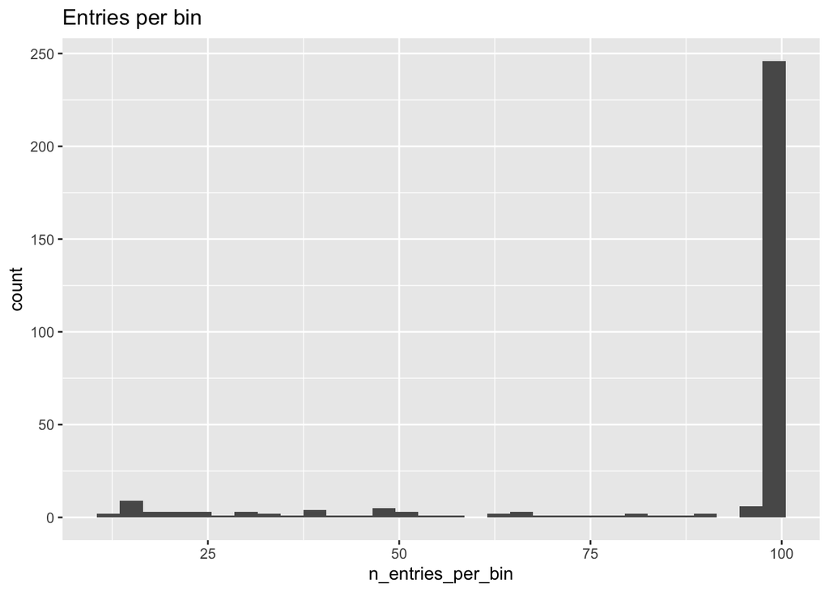

```r
# What size are bins?
ggplot(bin_check) +
  geom_histogram(aes(x=n_entries_per_bin)) +
  ggtitle("Entries per bin")
```

```r
#
# # Which bins have only one entry?
# subset(bin_check, n_entries_per_bin == 1)

print("How many bins have between 1 and 99 results?")
```

```
## [1] "How many bins have between 1 and 99 results?"
```

```r
length(which(bin_check$n_entries_per_bin > 0 & bin_check$n_entries_per_bin < 100))
```

```
## [1] 76
```

```r
print("How many detected outlier genes total are being analyzed?")
```

```
## [1] "How many detected outlier genes total are being analyzed?"
```

```r
sum(bin_check$n_entries_per_bin)
```

```
## [1] 27616
```

```r
# Get numbers before excluding NAs

bin_check_with_nas <- bulk_results_with_nas %>%
  group_by(Expression_bin, MEND_bin, length_bin) %>%
  summarize(n_entries_per_bin = n())
print("How many bins contain entries in this data?")
```

```
## [1] "How many bins contain entries in this data?"
```

```r
nrow(bin_check_with_nas)
```

```
## [1] 360
```

```r
print("How many bins have between 1 and 99 results?")
```

```
## [1] "How many bins have between 1 and 99 results?"
```

```r
length(which(bin_check_with_nas$n_entries_per_bin > 0 & bin_check_with_nas$n_entries_per_bin < 100))
```

```
## [1] 99
```

# Confirm the absence of NA values

```r
dim(bulk_results)
```

```
## [1] 27616    12
```

```r
dim(is.na(bulk_results))
```

```
## [1] 27616    12
```

```r
sum(is.na(bulk_results$Mean_Accuracy))
```

```
## [1] 0
```

## Profile of MEND depths

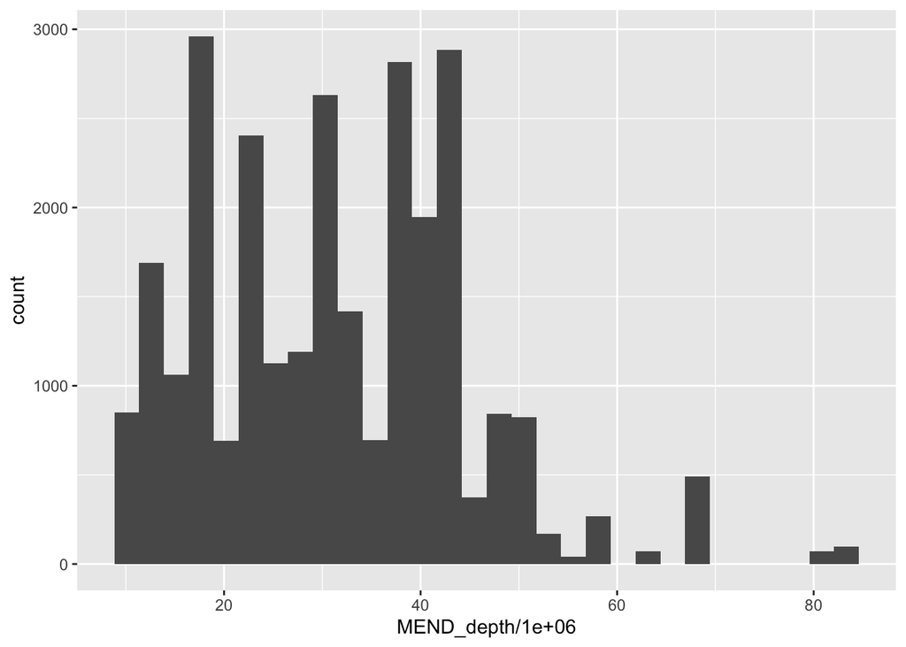

```r
just_MEND_depths <- bulk_results %>%
  select(Sample, MEND_depth)

ggplot(just_MEND_depths) +
  geom_histogram(aes(x=MEND_depth/1E6))
```

```r
range(just_MEND_depths$MEND_depth/1e6)
```

```
## [1] 10.49737 83.73758
```

```r
range(summary(just_MEND_depths$MEND_depth/1e6))
```

```
## [1] 10.49737 83.73758
```

## Number of outlier leads per sample

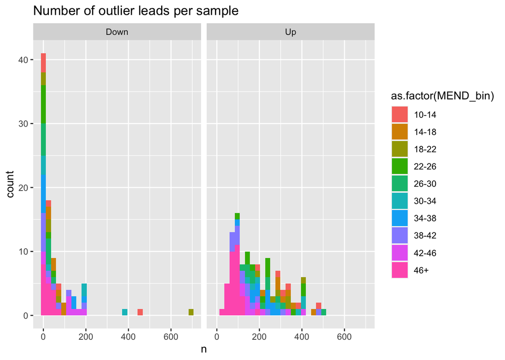

```r
# Histogram of number of outlier leads per sample (split by outlier type & fill is depth)

num_leads <- bulk_results %>% group_by(Sample, Type, MEND_bin) %>% tally()

plot1 <- ggplot(num_leads, aes(x=n, fill=as.factor(MEND_bin))) +
  geom_histogram() +
  facet_wrap(~Type) +
  ggtitle("Number of outlier leads per sample")

plot1
```

## Look at bin sizes

```r
# Make sure (depth, expression, length) bins are relatively similar sizes

all_bins <- bulk_results %>% tabyl(MEND_bin, Expression_bin, length_bin)

all_bins
```

```
## $`0-100`
##  MEND_bin 0-1 1-3 3-5 5-7 7-10 10-20
##       0-2   0   0   0   0    0     0
##       2-6   0   0   0   0    0     0
##      6-10   0   0   0   0    0     0
##     10-14  98 100 100   0    0     0
##     14-18  97 100 100   0    0     0
##     18-22 100 100 100   0    0     0
##     22-26  99 100 100   0    0     0
##     26-30  99 100 100   0    0     0
##     30-34  97 100 100   0    0     0
##     34-38 100 100 100   0    0     0
##     38-42  97 100 100   0    0     0
##     42-46 100 100 100   0    0     0
##       46+ 100 100 100   0    0     0
##
## $`100-450`
##  MEND_bin 0-1 1-3 3-5 5-7 7-10 10-20
##       0-2   0   0   0   0    0     0
##       2-6   0   0   0   0    0     0
##      6-10   0   0   0   0    0     0
##     10-14 100 100 100  48   27    15
##     14-18 100 100 100  74   47    22
##     18-22  99 100 100  91   62    19
##     22-26 100 100 100  90   41    16
##     26-30 100 100 100 100   31    22
##     30-34 100 100 100 100   96    15
##     34-38 100 100 100 100  100    31
##     38-42 100 100 100 100  100    48
##     42-46 100 100 100 100  100    49
##       46+ 100 100 100 100  100    85
##
## $`450-800`
##  MEND_bin 0-1 1-3 3-5 5-7 7-10 10-20
##       0-2   0   0   0   0    0     0
##       2-6   0   0   0   0    0     0
##      6-10   0   0   0   0    0     0
##     10-14 100 100 100  80   66    23
##     14-18 100 100 100  63   72    38
##     18-22 100 100 100  82   69    17
```

[output cut: 40 more lines]

```
## $`4000+`
##  MEND_bin 0-1 1-3 3-5 5-7 7-10 10-20
##       0-2   0   0   0   0    0     0
##       2-6   0   0   0   0    0     0
##      6-10   0   0   0   0    0     0
##     10-14 100 100 100  58   14     0
##     14-18 100 100 100  47   16     0
##     18-22 100 100 100  65   23     0
##     22-26  99 100 100 100   46     0
##     26-30 100 100 100 100   39     0
##     30-34 100 100 100 100   30     0
##     34-38 100 100 100 100   52     0
##     38-42 100 100 100 100  100     0
##     42-46  97 100 100 100   65     0
##       46+ 100 100 100 100  100     0
```

## How many outliers had >95% accuracy?

```r
print("How many outliers had >95% accuracy?")
```

```
## [1] "How many outliers had >95% accuracy?"
```

```r
length(which(bulk_results$Mean_Accuracy > 0.95))
```

```
## [1] 17362
```

```r
print("What percent of outliers had >95% accuracy?")
```

```
## [1] "What percent of outliers had >95% accuracy?"
```

```r
100*length(which(bulk_results$Mean_Accuracy > 0.95))/nrow(bulk_results)
```

```
## [1] 62.86935
```

## Spectrum of accuracies by depth, expression, and length

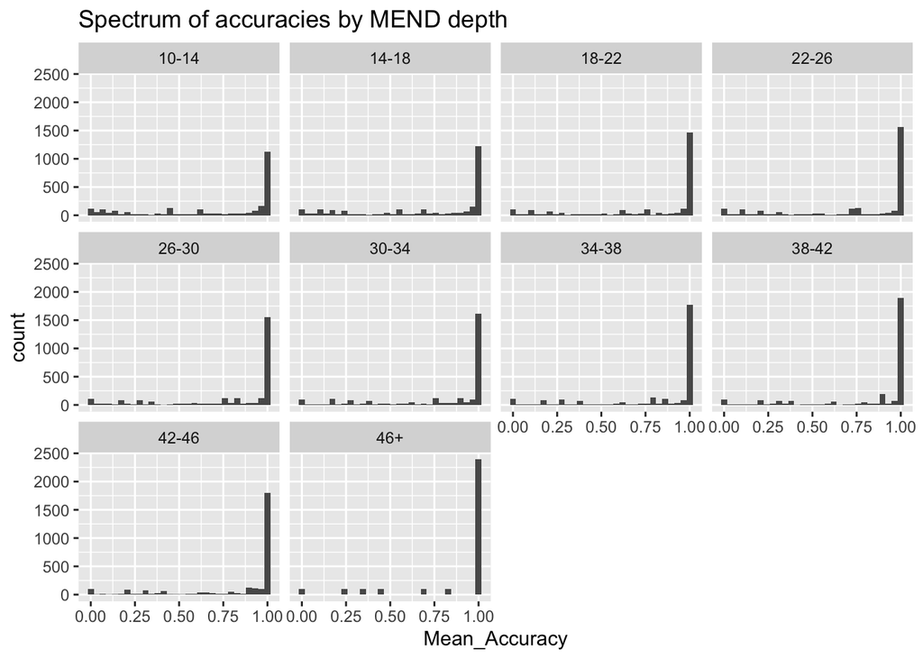

```r
plot2 <- ggplot(bulk_results, aes(x=Mean_Accuracy)) +
  geom_histogram() +
  facet_wrap(~MEND_bin) +
  ggtitle("Spectrum of accuracies by MEND depth")

plot2
```

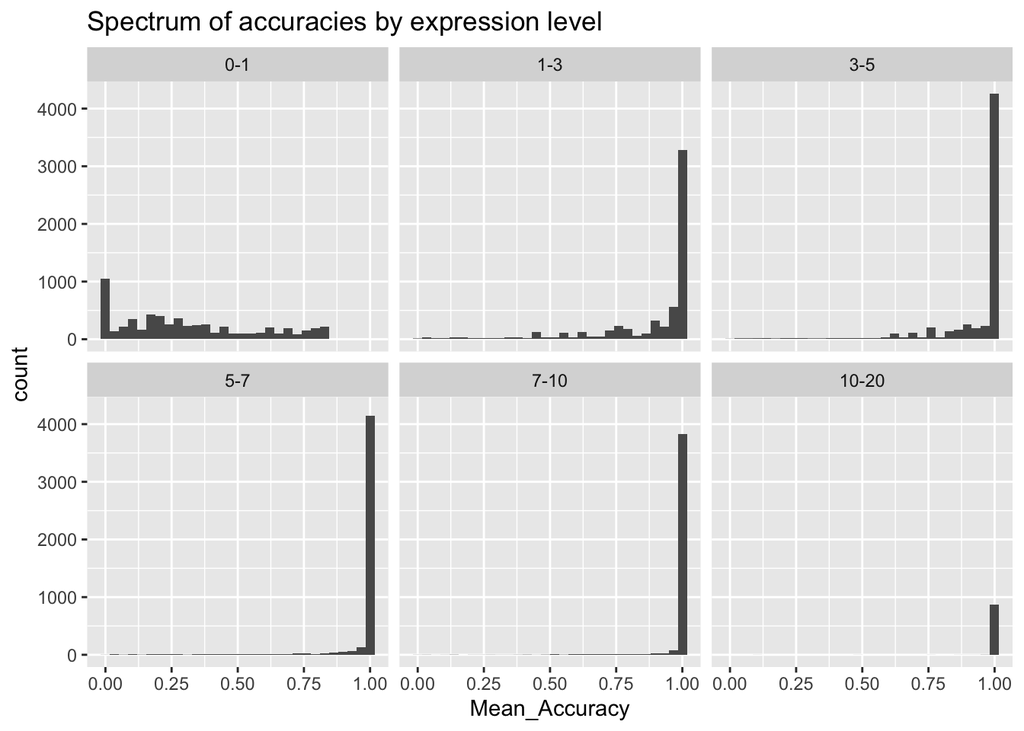

```r
plot3 <- ggplot(bulk_results, aes(x=Mean_Accuracy)) +
  geom_histogram() +
  facet_wrap(~Expression_bin) +
  ggtitle("Spectrum of accuracies by expression level")

plot3
```

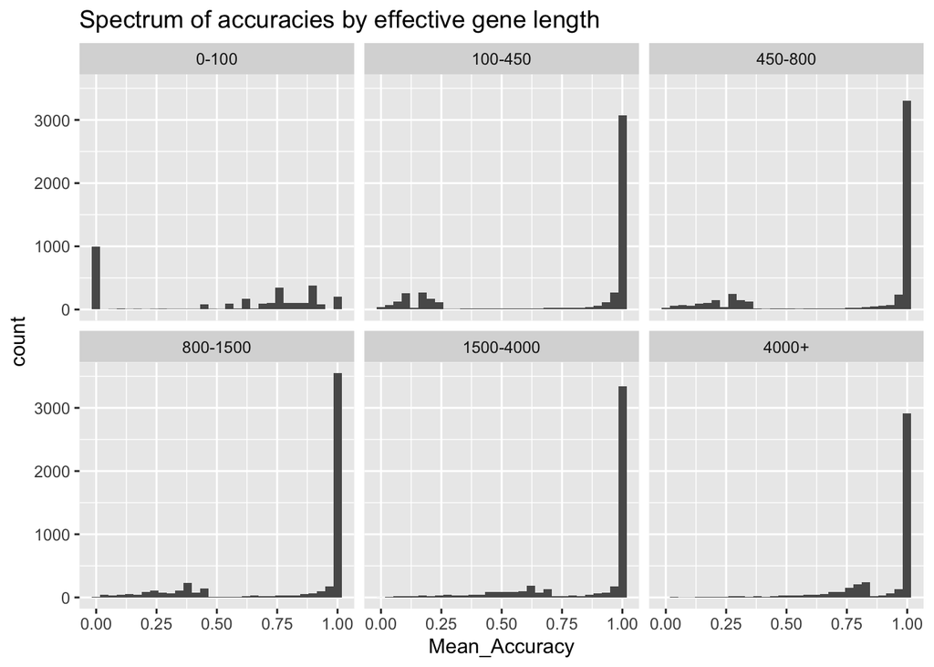

```r
plot4 <- ggplot(bulk_results, aes(x=Mean_Accuracy)) +
  geom_histogram() +
  facet_wrap(~length_bin) +
  ggtitle("Spectrum of accuracies by effective gene length")

plot4
```

### Looking at the very low accuracy up outliers

```r
# Outliers with probability < 0.05
low_acc_ups <- subset(bulk_results, Mean_Accuracy < 0.05)

# How many are there?
nrow(low_acc_ups)
```

```
## [1] 1256
```

```r
# What percent are short & low exp?
100*length(which(low_acc_ups$Expression_bin == "0-1" & low_acc_ups$length_bin == "0-100"))/nrow(low_acc_ups)
```

```
## [1] 78.5828
```

# Spectrum of accuracies by outlier type (histograms for figure 1)

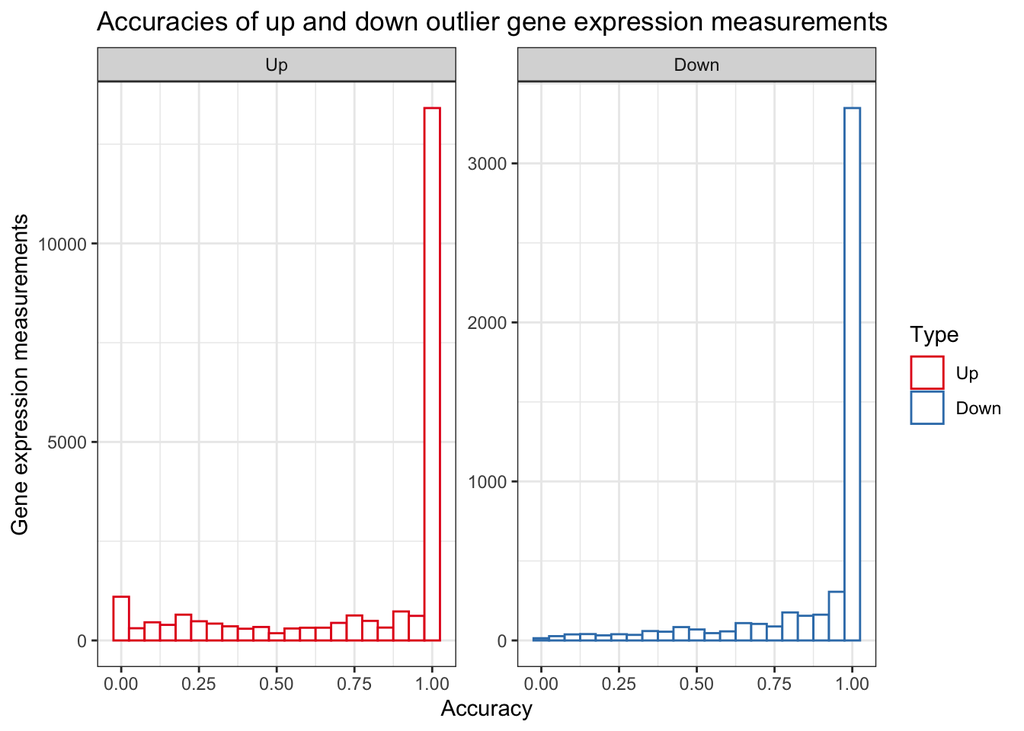

```r
bulk_results$Type <- factor(bulk_results$Type, levels = c("Up", "Down"))

acc_overview <- ggplot(bulk_results, aes(x=Mean_Accuracy, color=Type)) +
  geom_histogram(fill="white", binwidth = 0.05) +
  facet_wrap(~Type, scales="free") +
  scale_color_brewer(palette = "Set1") +
  theme_bw() +
  xlab("Accuracy") +
  ylab("Gene expression measurements") +
  ggtitle("Accuracies of up and down outlier gene expression measurements")

acc_overview
```

```r
ggsave("../figures/accuracies_all.png", acc_overview)
```

# Distributions of accuracies for different expressions, depths, and lengths (boxplots for figure 1)

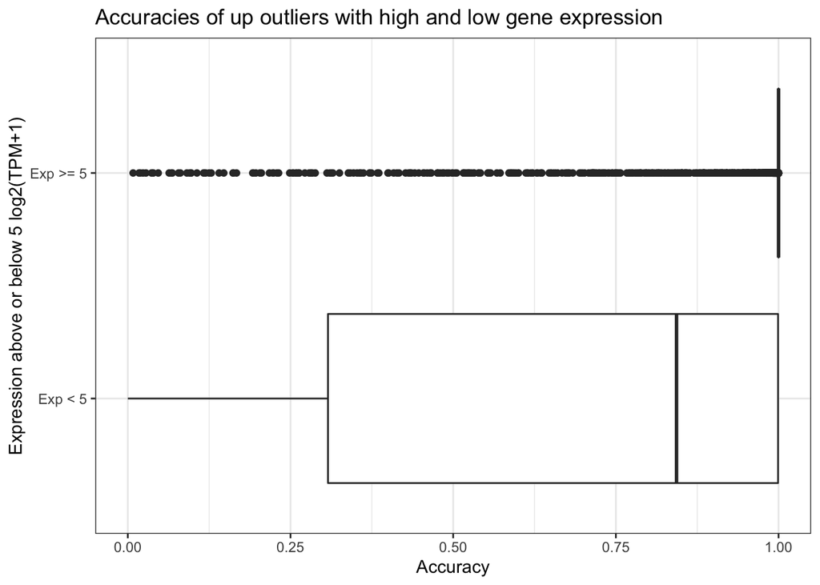

```r
figure1_data <- bulk_results %>%
  mutate(exp_gt5 = Expression >= 5,
         depth_gt20 = MEND_bin >= 20,
         length_gt1000 = effective_length >= 1000)
# Expression above or below 5

ggplot(subset(figure1_data, Type == "Up"), aes(x=exp_gt5, y=Mean_Accuracy)) +
  geom_boxplot() +
  coord_flip() +
  theme_bw() +
  scale_x_discrete(labels=c("TRUE"="Exp >= 5", "FALSE"="Exp < 5")) +
  ylab("Accuracy") +
  xlab("Expression above or below 5 log2(TPM+1)") +
  ggtitle("Accuracies of up outliers with high and low gene expression")
```

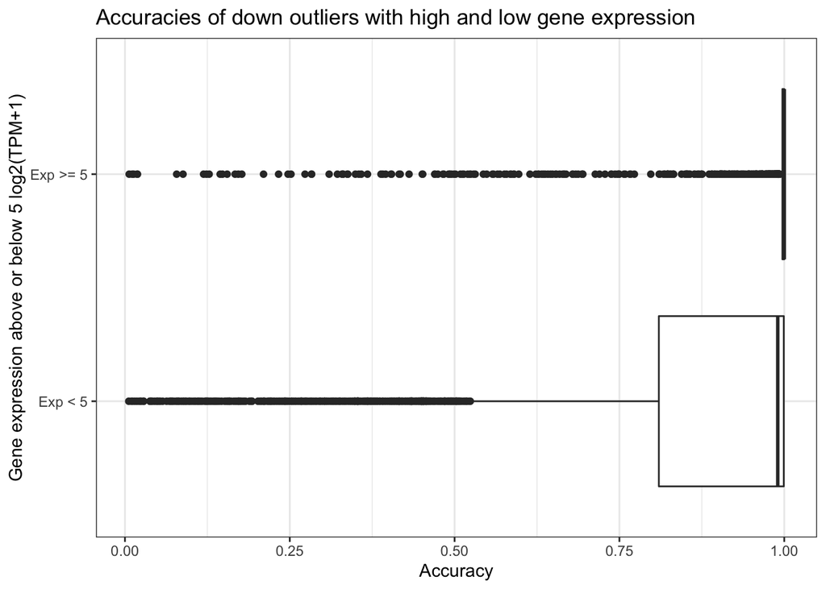

```r
ggsave("..//figures/accuracies_up_exp.png")
ggplot(subset(figure1_data, Type == "Down"), aes(x=exp_gt5, y=Mean_Accuracy)) +
  geom_boxplot() +
  coord_flip() +
  theme_bw() +
  scale_x_discrete(labels=c("TRUE"="Exp >= 5", "FALSE"="Exp < 5")) +
  ylab("Accuracy") +
  xlab("Gene expression above or below 5 log2(TPM+1)") +
  ggtitle("Accuracies of down outliers with high and low gene expression")
```

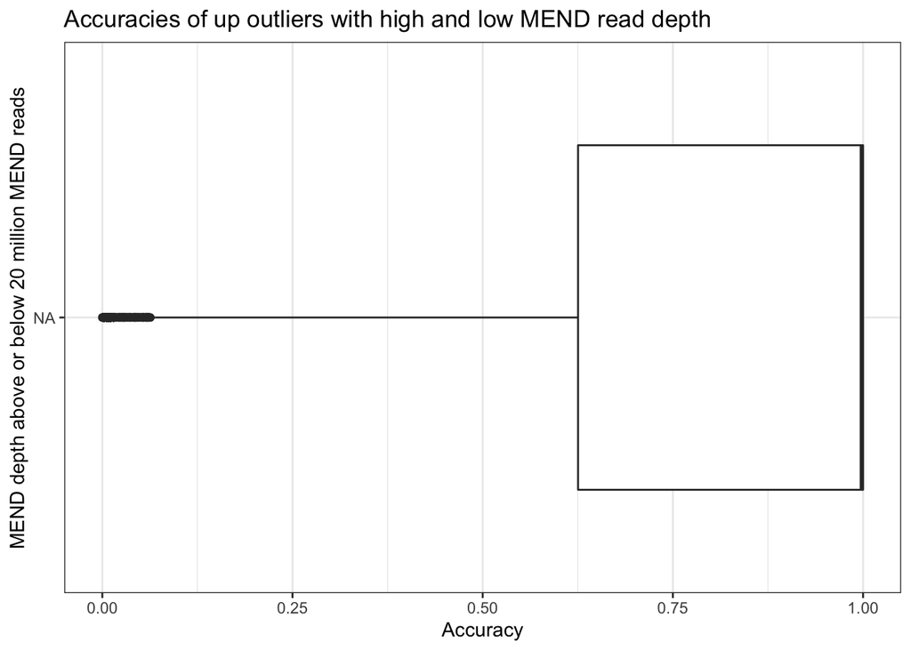

```r
ggsave("..//figures/accuracies_down_exp.png")
# Depth above or below 20

ggplot(subset(figure1_data, Type == "Up"), aes(x=depth_gt20, y=Mean_Accuracy)) +
  geom_boxplot() +
  coord_flip() +
  theme_bw() +
  scale_x_discrete(labels=c("TRUE"="Depth >= 20", "FALSE"="Depth < 20")) +
  ylab("Accuracy") +
  xlab("MEND depth above or below 20 million MEND reads") +
  ggtitle("Accuracies of up outliers with high and low MEND read depth")
```

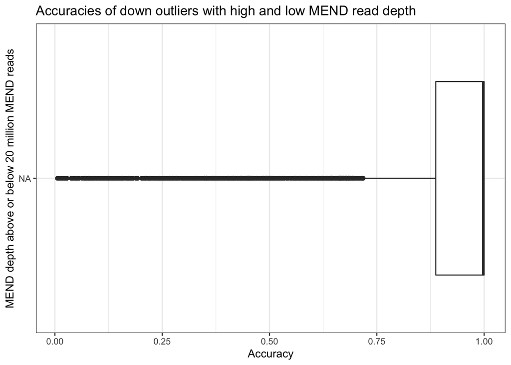

```r
ggsave("..//figures/accuracies_up_depth.png")
ggplot(subset(figure1_data, Type == "Down"), aes(x=depth_gt20, y=Mean_Accuracy)) +
  geom_boxplot() +
  coord_flip() +
  theme_bw() +
  scale_x_discrete(labels=c("TRUE"="Depth >= 20", "FALSE"="Depth < 20")) +
  ylab("Accuracy") +
  xlab("MEND depth above or below 20 million MEND reads") +
  ggtitle("Accuracies of down outliers with high and low MEND read depth")
```

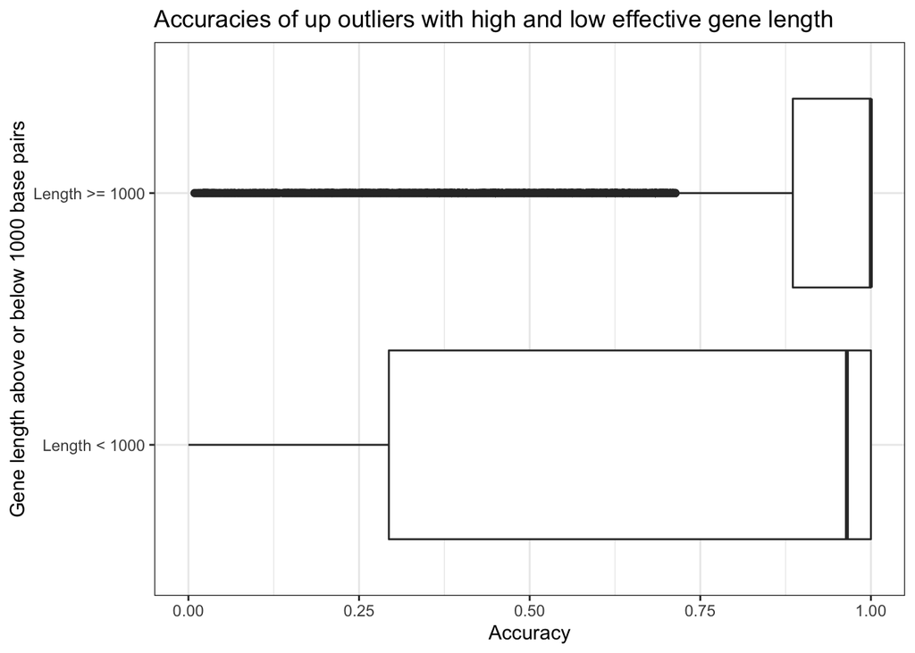

```r
ggsave("..//figures/accuracies_down_depth.png")
# Length above or below 1000

ggplot(subset(figure1_data, Type == "Up"), aes(x=length_gt1000, y=Mean_Accuracy)) +
  geom_boxplot() +
  coord_flip() +
  theme_bw() +
  scale_x_discrete(labels=c("TRUE"="Length >= 1000", "FALSE"="Length < 1000")) +
  ylab("Accuracy") +
  xlab("Gene length above or below 1000 base pairs") +
  ggtitle("Accuracies of up outliers with high and low effective gene length")
```

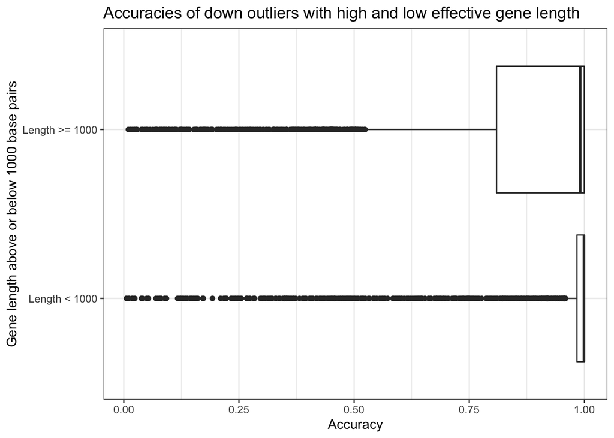

```r
ggsave("..//figures/accuracies_up_length.png")
ggplot(subset(figure1_data, Type == "Down"), aes(x=length_gt1000, y=Mean_Accuracy)) +
  geom_boxplot() +
  coord_flip() +
  theme_bw() +
  scale_x_discrete(labels=c("TRUE"="Length >= 1000", "FALSE"="Length < 1000")) +
  ylab("Accuracy") +
  xlab("Gene length above or below 1000 base pairs") +
  ggtitle("Accuracies of down outliers with high and low effective gene length")
```

```r
ggsave("..//figures/accuracies_down_length.png")
```

# StatBin2 function def

```r
# StatBin2 allows depiction of empty bins as blank instead of a horizontal line:
# https://stackoverflow.com/questions/57128090/remove-baseline-color-for-geom-histogram
StatBin2 <- ggproto(
  "StatBin2",
  StatBin,
  compute_group = function (data, scales, binwidth = NULL, bins = NULL,
                            center = NULL, boundary = NULL,
                            closed = c("right", "left"), pad = FALSE,
                            breaks = NULL, origin = NULL, right = NULL,
                            drop = NULL, width = NULL) {
    if (!is.null(breaks)) {
      if (!scales$x$is_discrete()) {
        breaks <- scales$x$transform(breaks)
      }
      bins <- ggplot2:::bin_breaks(breaks, closed)
    }
    else if (!is.null(binwidth)) {
      if (is.function(binwidth)) {
        binwidth <- binwidth(data$x)
      }
      bins <- ggplot2:::bin_breaks_width(scales$x$dimension(), binwidth,
                                         center = center, boundary = boundary,
                                         closed = closed)
    }
    else {
      bins <- ggplot2:::bin_breaks_bins(scales$x$dimension(), bins,
                                        center = center, boundary = boundary,
                                        closed = closed)
    }
    res <- ggplot2:::bin_vector(data$x, bins, weight = data$weight, pad = pad)

    # drop 0-count bins completely before returning the dataframe
    res <- res[res$count > 0, ]

    res
  })
```

# Look at the distribution of percent difference values to pick a split

```r
summary(bulk_results$`Percent difference`)
```

```
##     Min.  1st Qu.   Median     Mean  3rd Qu.     Max.
##    0.001   12.383   44.462   55.611   93.278 8043.910
```

```r
summary(bulk_results$MEND_depth)
```

```
##     Min.  1st Qu.   Median     Mean  3rd Qu.     Max.
## 10497367 20883771 30504521 31360326 40599000 83737577
```

```r
summary(bulk_results$effective_length)
```

```
##     Min.  1st Qu.   Median     Mean  3rd Qu.     Max.
##      0.0    393.8    896.4   1807.6   2181.7 204871.6
```

```r
summary(bulk_results$Expression)
```

```
##     Min.  1st Qu.   Median     Mean  3rd Qu.     Max.
##  0.01435  1.20477  3.44626  3.87465  5.94433 18.62126
```

```r
median(bulk_results$`Percent difference`)
```

```
## [1] 44.46213
```

```r
median(bulk_results$MEND_depth)
```

```
## [1] 30504521
```

```r
median(bulk_results$effective_length)
```

```
## [1] 896.4
```

```r
median(bulk_results$Expression)
```

```
## [1] 3.446256
```

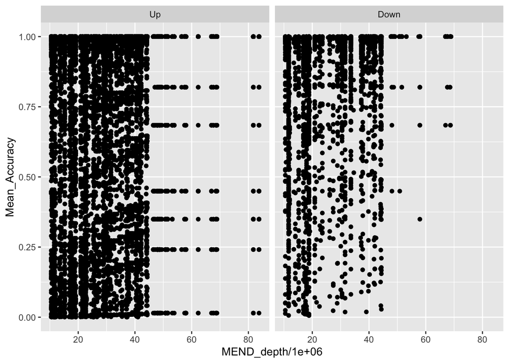

```r
ggplot(bulk_results) +
  geom_point(aes(x=MEND_depth/1e6, y=Mean_Accuracy)) +
  facet_wrap(~Type)
```

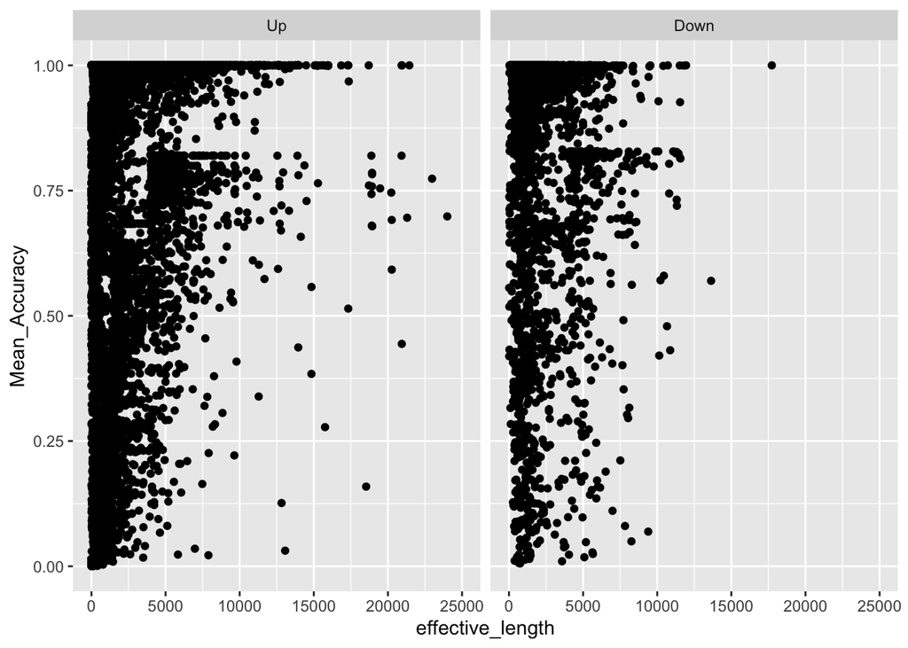

```r
ggplot(bulk_results) +
  geom_point(aes(x=effective_length, y=Mean_Accuracy)) +
  facet_wrap(~Type) +
  xlim(0, 25000)
```

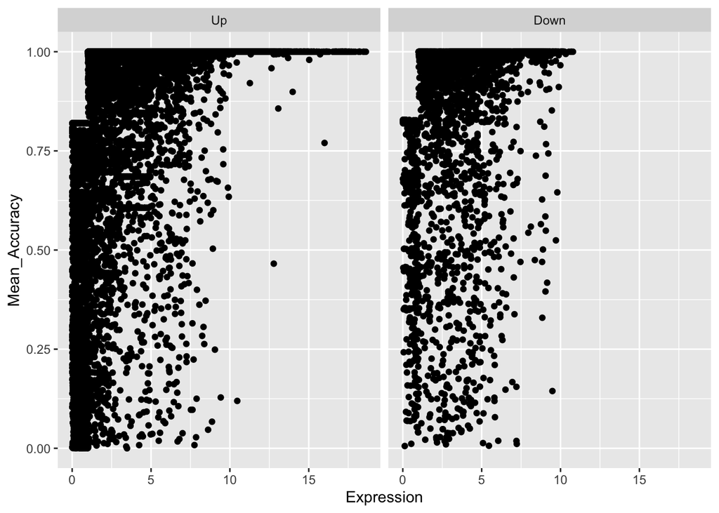

```r
ggplot(bulk_results) +
  geom_point(aes(x=Expression, y=Mean_Accuracy)) +
  facet_wrap(~Type)
```

# Figure 1

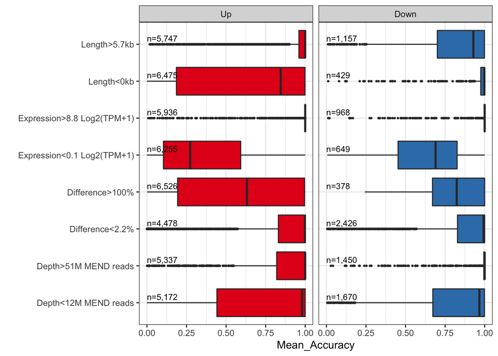

```r
# to get hex codes from palette
# library(RColorBrewer)
# brewer.pal(12, "Set1")

type_colors = c(Up = "#E41A1C", Down = "#377EB8")

bulk_results$Type <- factor(bulk_results$Type, levels = c("Up", "Down"))

acc_overview <- ggplot(bulk_results, aes(x=Mean_Accuracy, color=Type)) +
  geom_histogram(fill="white", stat = StatBin2) +
  facet_wrap(~Type, scales="free") +
  theme_bw() +
  scale_color_manual(values = type_colors) +
  theme(legend.position="none") +
  xlab("") +
  ylab("Gene\nexpression\nmeasurements")

figure1_data_v2 <- bind_rows(
bulk_results %>%
  filter(Expression > quantile(Expression, 0.75)) %>%
  mutate(set = paste0("Expression>", round(quantile(Expression, 0.75), 1), " Log2(TPM+1)")),
bulk_results %>%
  filter(Expression < quantile(Expression, 0.25)) %>%
  mutate(set = paste0("Expression<", round(quantile(Expression, 0.25), 1), " Log2(TPM+1)")),
bulk_results %>%
  filter(MEND_depth > quantile(MEND_depth, 0.75)) %>%
  mutate(set = paste0("Depth>", round(quantile(MEND_depth, 0.75)/1e6), "M MEND reads")),
bulk_results %>%
  filter(MEND_depth < quantile(MEND_depth, 0.25)) %>%
  mutate(set = paste0("Depth<", round(quantile(MEND_depth, 0.25)/1e6), "M MEND reads")),
bulk_results %>%
  filter(effective_length > quantile(effective_length, 0.75)) %>%
  mutate(set = paste0("Length>", round(quantile(effective_length, 0.75)/1000, 1), "kb")),
bulk_results %>%
  filter(effective_length < quantile(effective_length, 0.25)) %>%
  mutate(set = paste0("Length<", round(quantile(effective_length, 0.25)/1000, 1), "kb")),
bulk_results %>%
  filter(`Percent difference` > quantile(`Percent difference`, 0.75)) %>%
  mutate(set = paste0("Difference>", round(quantile(`Percent difference`, 0.75), 1), "%")),
bulk_results %>%
  filter(`Percent difference` < quantile(`Percent difference`, 0.25)) %>%
  mutate(set = paste0("Difference<", round(quantile(`Percent difference`, 0.25), 1), "%"))
)

boxplot_n_labels <- figure1_data_v2 %>%
   group_by(set, Type) %>%
   summarize(set_type_label = paste0("n=", scales::label_comma()(n())))
all_boxplots <- ggplot(figure1_data_v2, aes(y=set, x=Mean_Accuracy, fill = Type)) +
  geom_boxplot(outlier.size = 0.5) +
  geom_text(data = boxplot_n_labels,
            #aes(x=0.50, y=set, label = set_type_label), vjust = -1, size = 3) +
            aes(x=0, y=set, label = set_type_label), vjust = -0.5, hjust = 0, size = 3) +
  theme_bw() +
  scale_fill_manual(values = type_colors) +
  scale_color_manual(values = type_colors) +
  facet_wrap(~Type, ncol = 2) +
  theme(legend.position="none") +
  ylab("")

all_boxplots
```

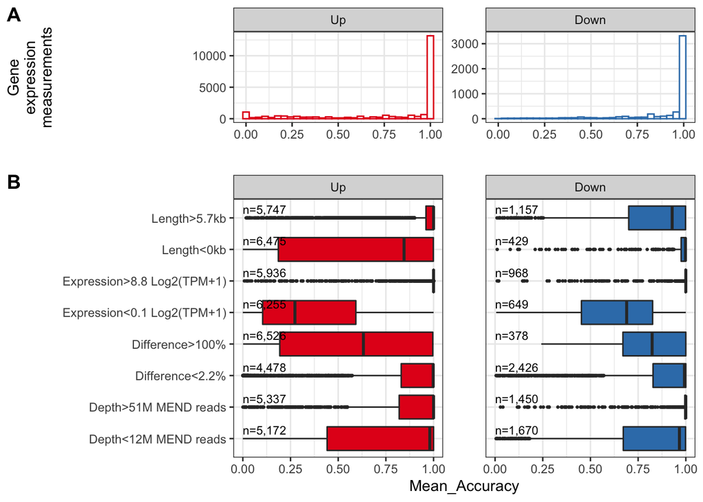

```r
combined_image <- plot_grid(acc_overview, all_boxplots, ncol = 1, rel_heights = c(1,2), align = "v",
                  labels = "AUTO")
combined_image
```

```r
ggsave("../figures/fig1.png", combined_image)
```

Notes: the reason that, for up-outliers, difference == 100% has a median lower than difference < 2% is because the difference is only 100 when the threshold is 0. Usually these are low expressed genes, so they get the max mean accuracy of 88% (or whatever the exact numbers are)

Random calculations for the paper

```r
# Average number of up and down outliers per sample

mean(subset(num_leads, Type == "Up")$n)
```

```
## [1] 196.287
```

```r
mean(subset(num_leads, Type == "Down")$n)
```

```
## [1] 55.41758
```

```r
median(subset(num_leads, Type == "Up")$n)
```

```
## [1] 170
```

```r
median(subset(num_leads, Type == "Down")$n)
```

```
## [1] 13
```

```r
# Average accuracies of up and down outliers per sample

mean(subset(figure1_data, Type == "Up" & !is.na(Mean_Accuracy))$Mean_Accuracy)
```

```
## [1] 0.7816667
```

```r
mean(subset(figure1_data, Type == "Down" & !is.na(Mean_Accuracy))$Mean_Accuracy)
```

```
## [1] 0.8872466
```

```r
median(subset(figure1_data, Type == "Up" & !is.na(Mean_Accuracy))$Mean_Accuracy)
```

```
## [1] 0.9981488
```

```r
median(subset(figure1_data, Type == "Down" & !is.na(Mean_Accuracy))$Mean_Accuracy)
```

```
## [1] 0.9977485
```

```r
# Fraction of accuracies above 95%

count(subset(figure1_data, Type == "Up" & Mean_Accuracy>95)) /
  count(subset(figure1_data, Type == "Up"))
```

```
##   n
## 1 0
```

```r
count(subset(figure1_data, Type == "Down" & Mean_Accuracy>95)) /
  count(subset(figure1_data, Type == "Down"))
```

```
##   n
## 1 0
```

```r
count(subset(figure1_data, Mean_Accuracy>95)) /
  count(figure1_data)
```

```
##   n
## 1 0
```

```r
# the bump in distribution due to the 0-1 crowd

median(subset(figure1_data, Expression_bin == "0-1")$Mean_Accuracy)
```

```
## [1] 0.2545354
```

# Look into the percent difference results

```r
pd2 <- figure1_data_v2 %>%
  filter(set == "Difference<2.2%")

pd100 <- figure1_data_v2 %>%
  filter(set == "Difference>100%")

print("pd2 summary")
```

```
## [1] "pd2 summary"
```

```r
summary(pd2$Mean_Accuracy)
```

```
##    Min. 1st Qu.  Median    Mean 3rd Qu.    Max.
##  0.0000  0.8288  0.9971  0.8394  1.0000  1.0000
```

```r
summary(pd2$Expression)
```

```
##    Min. 1st Qu.  Median    Mean 3rd Qu.    Max.
##   0.111   3.532   5.573   5.559   7.465  17.690
```

```r
print("pd100 summary")
```

```
## [1] "pd100 summary"
```

```r
summary(pd100$Mean_Accuracy)
```

```
##     Min.  1st Qu.   Median     Mean  3rd Qu.     Max.
## 0.001315 0.203232 0.672917 0.576530 0.997375 1.000000
```

```r
summary(pd100$Expression)
```

```
##     Min.  1st Qu.   Median     Mean  3rd Qu.     Max.
##  0.01435  0.15056  0.98550  1.95270  3.19417 16.07145
```

```r
print("pd100 up summary")
```

```
## [1] "pd100 up summary"
```

```r
summary(pd100$Mean_Accuracy[pd100$Type == "Up"])
```

```
##     Min.  1st Qu.   Median     Mean  3rd Qu.     Max.
## 0.001315 0.193630 0.632173 0.564330 0.995919 1.000000
```

```r
summary(pd100$Expression[pd100$Type == "Up"])
```

```
##     Min.  1st Qu.   Median     Mean  3rd Qu.     Max.
##  0.01435  0.15056  1.04664  2.02079  3.28651 16.07145
```

```r
print("pd100 down summary")
```

```
## [1] "pd100 down summary"
```

```r
summary(pd100$Mean_Accuracy[pd100$Type == "Down"])
```

```
##    Min. 1st Qu.  Median    Mean 3rd Qu.    Max.
##  0.2422  0.6702  0.8234  0.7872  0.9999  1.0000
```

```r
summary(pd100$Expression[pd100$Type == "Down"])
```

```
##    Min. 1st Qu.  Median    Mean 3rd Qu.    Max.
## 0.01435 0.18903 0.56071 0.77718 1.14241 4.36667
```

# SessionInfo

```r
library(pander) # to make session info
pander(sessionInfo(), compact = FALSE)
```

**R version 3.6.1 (2019-07-05)**

**Platform:** x86_64-apple-darwin15.6.0 (64-bit)

**locale:** en_US.UTF-8||en_US.UTF-8||en_US.UTF-8||C||en_US.UTF-8||en_US.UTF-8

**attached base packages:**

- stats
- graphics
- grDevices
- utils
- datasets
- methods
- base

**other attached packages:**

- pander(v.0.6.3)
- cowplot(v.1.0.0)
- janitor(v.1.2.0)
- forcats(v.0.4.0)
- stringr(v.1.4.0)
- dplyr(v.1.0.2)
- purrr(v.0.3.3)
- readr(v.1.3.1)
- tidyr(v.1.0.2)
- tibble(v.3.0.4)
- ggplot2(v.3.3.2)
- tidyverse(v.1.3.0)
- scales(v.1.1.1)

**loaded via a namespace (and not attached):**

- tidyselect(v.1.1.0)
- xfun(v.0.9)
- haven(v.2.3.1)
- lattice(v.0.20-38)
- colorspace(v.2.0-0)
- vctrs(v.0.3.5)
- generics(v.0.0.2)
- htmltools(v.0.4.0)
- yaml(v.2.2.0)
- rlang(v.0.4.9)
- pillar(v.1.4.7)
- glue(v.1.4.2)
- withr(v.2.3.0)
- DBI(v.1.0.0)
- RColorBrewer(v.1.1-2)
- dbplyr(v.1.4.2)
- modelr(v.0.1.5)
- readxl(v.1.3.1)
- lifecycle(v.0.2.0)
- munsell(v.0.5.0)
- gtable(v.0.3.0)
- cellranger(v.1.1.0)
- rvest(v.0.3.6)
- evaluate(v.0.14)
- labeling(v.0.4.2)
- knitr(v.1.25)
- fansi(v.0.4.1)
- broom(v.0.5.2)
- Rcpp(v.1.0.2)
- backports(v.1.1.4)
- jsonlite(v.1.7.1)
- farver(v.2.0.3)
- fs(v.1.3.1)
- hms(v.0.5.3)
- digest(v.0.6.27)
- stringi(v.1.4.3)
- grid(v.3.6.1)
- cli(v.2.2.0)
- tools(v.3.6.1)
- magrittr(v.2.0.1)
- crayon(v.1.3.4)
- pkgconfig(v.2.0.3)
- ellipsis(v.0.3.1)
- xml2(v.1.2.2)
- reprex(v.0.3.0)
- lubridate(v.1.7.4)
- assertthat(v.0.2.1)
- rmarkdown(v.1.15)
- httr(v.1.4.1)
- rstudioapi(v.0.13)
- R6(v.2.5.0)
- nlme(v.3.1-141)
- compiler(v.3.6.1)